# Tutorial - ggplot2

Emily Sheen

2/22/2019

## Helpful Links

This tutorial was created using other tutorials and helpful websites, which I recommend bookmarking:

- http://r-statistics.co/Top50-Ggplot2-Visualizations-MasterList-R-Code.html
- https://www.r-graph-gallery.com/
- http://zevross.com/blog/2014/08/04/beautiful-plotting-in-r-a-ggplot2-cheatsheet-3/
- http://colorbrewer2.org/
- http://eriqande.github.io/rep-res-web/lectures/making-maps-with-R.html
- http://www.sthda.com/english/wiki/ggplot2-axis-ticks-a-guide-to-customize-tick-marks-and-labels

## Notes on R Markdown

This document was created with R Markdown, which blends text, LaTex, and R code to create quick and presentable html or pdf documents. See the following link for an introduction to R Markdown: https://kbroman.org/knitr_knutshell/pages/Rmarkdown.html. Chunks of R code are distinguished by:

```r
# put R code here
2 + 2
```

```
## [1] 4
```

You can change what gets “knitted” into the final pdf/html document using the following commands at the top of the R chunk: `echo = FALSE`

- `echo = FALSE`: R code will not be printed, output is still printed
- `results = "hide"`: hide the results/output (but code is still run and displayed if `echo = TRUE`)
- `include = FALSE`: R code is evaluated, but neither code nor output is printed in pdf/html

## Setup

First, import the data from Github using the following code. We will be using data from Tidy Tuesday, which you can check out here: https://github.com/rfordatascience/tidytuesday, or by searching #TidyTuesday on Twitter. These particular datasets look at milk production in the US. The Data Dictionaries can be found here: https://github.com/rfordatascience/tidytuesday/blob/master/data/2019/2019-01-29/readme.md

```r
#Install packages if you do not already have them (uncomment this code)
# install.packages(c("readr", "curl"))
# install.packages(c("ggplot2", "devtools", "dplyr", "stringr"))
# install.packages(c("maps", "mapdata"))
library(devtools)
# devtools::install_github("dkahle/ggmap")

# Load necessary packages
library(devtools)
library(readr)
library(curl)
library(ggplot2)
library(dplyr)
library(stringr)
library(maps)
library(mapdata)
library(ggmap)


# import data from Tidy Tuesday source on Github
cheese <- readr::read_csv("https://raw.githubusercontent.com/rfordatascience/tidytuesday/master/data/2019/2019-01-29/clean_cheese.csv")
fluid_milk_sales <- readr::read_csv("https://raw.githubusercontent.com/rfordatascience/tidytuesday/master/data/2019/2019-01-29/fluid_milk_sales.csv")
milk_facts <- readr::read_csv("https://raw.githubusercontent.com/rfordatascience/tidytuesday/master/data/2019/2019-01-29/milk_products_facts.csv")
cow_facts <- readr::read_csv("https://raw.githubusercontent.com/rfordatascience/tidytuesday/master/data/2019/2019-01-29/milkcow_facts.csv")
state_milk0 <- readr::read_csv("https://raw.githubusercontent.com/rfordatascience/tidytuesday/master/data/2019/2019-01-29/state_milk_production.csv")
```

## Maps Example

See http://eriqande.github.io/rep-res-web/lectures/making-maps-with-R.html for the complete R tutorial.

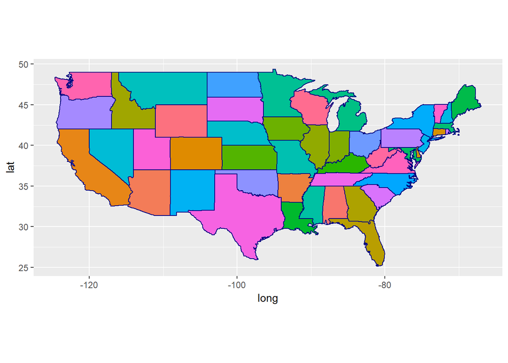

```r
# Create data frame for map data of USA, using map_data function
usa <- map_data("usa")
states <- map_data("state")
china <- map_data("world") %>% filter(region == "China")
mapChina <- ggplot(data = china) +
  geom_polygon(aes(x=long, y = lat, fill = region, group = group),
               color = "navy") +
  coord_fixed(1.1) + # aspect ratio = every y unit is 1.1 times longer than an x unit
  guides(fill = FALSE) # leave off legend
# mapChina


mapStates <- ggplot(data = states) +
  geom_polygon(aes(x=long, y = lat, fill = region, group = group),
               color = "navy") +
  coord_fixed(1.1) + # aspect ratio = every y unit is 1.1 times longer than an x unit
  guides(fill = FALSE) # leave off legend
mapStates #map each state with its own color
```

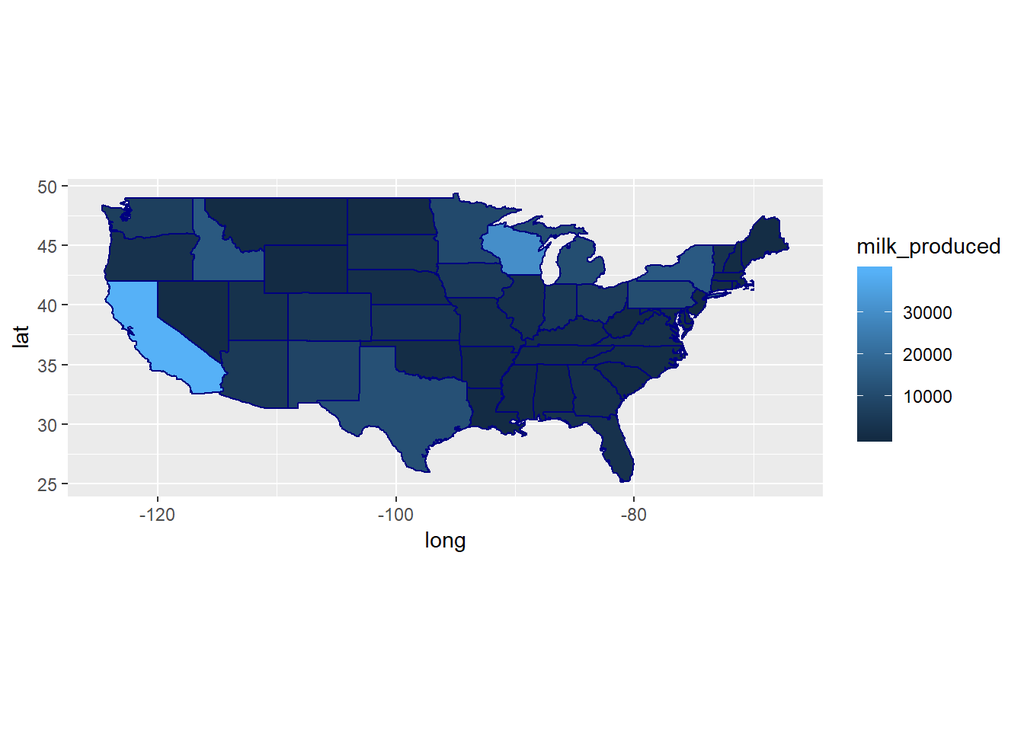

```r
#Now we will do a map of the states, except with milk production as the color
# We need to merge the geographic data from states dataframe, with milk data
#rename the columns of state_milk to be able to join it with states
names(state_milk0) <- c("big_region", "region", "year", "milk_produced")
state_milk <- state_milk0 %>% #convert milk production to millions lbs per year
  mutate_at("milk_produced", function(x){x/1000000}) %>%
  dplyr::select(-big_region) %>%   # get rid of big_region
  dplyr::mutate_at("region", tolower) %>%  #change to lower case like states dataframe
  dplyr::mutate_at("year", as.integer) %>%
  full_join(states, by = "region") %>%
  dplyr::select(-subregion)

state_milk_2017 <- state_milk %>%
  dplyr::filter(year == 2017) # only look at 2017 milk

milkMap <- ggplot(data = state_milk_2017) +
  geom_polygon(aes(x=long, y = lat, fill = milk_produced, group = group),
               color = "navy") +
  coord_fixed(1) # aspect ratio = every y unit is 1.1 times longer than an x unit
#  guides(fill = TRUE) # leave off legend
milkMap
```

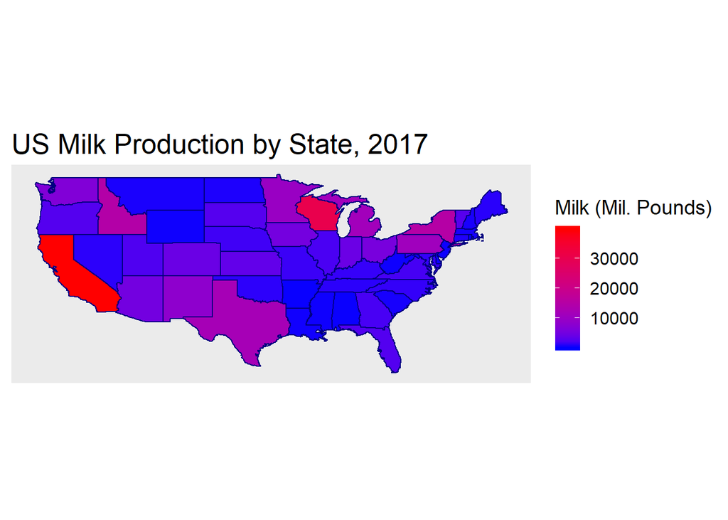

```r
# Create a theme to remove the axes' labels and tick marks
# if we wanted to remove everything, we could use theme_nothing()
ditch_the_axes <- theme(
  axis.text = element_blank(),
  axis.line = element_blank(),
  axis.ticks = element_blank(),
  panel.border = element_blank(),
  panel.grid = element_blank(),
  axis.title = element_blank(),
  title = element_text(size =16),
  legend.title = element_text(size = 14),
  legend.text = element_text(size = 12)
)

# change the color, remove axes labels
milkMap +
  scale_fill_gradient(low = "blue", high = "red",
                      breaks = c(10000,20000,30000,40000)) +
  ditch_the_axes + #removes axes, set text sizes
  labs(fill = "Milk (Mil. Pounds)") +
  ggtitle("US Milk Production by State, 2017")
```

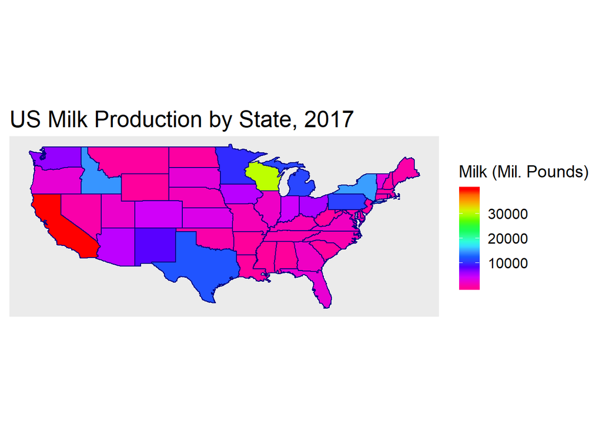

```r
#Make it rainbow
milkMap +
  scale_fill_gradientn(colours = rev(rainbow(10)),
                      breaks = c(10000,20000,30000,40000),
                      trans = "identity") +
  ditch_the_axes +
  labs(fill = "Milk (Mil. Pounds)") +
  ggtitle("US Milk Production by State, 2017")
```

```r
path <- "C:/Users/eshee/Box Sync/Documents/Penn State Statistics/Research/B2D2K/ggplot2_tutorial"

ggsave(filename = "Fig1-USMilkProdMap.png",
       plot = last_plot(),width = 30, height = 22, units = "cm",
       dpi = 300, device = "png", path = path)      #save plot
```

## Maps with Google Maps

We can also create maps from Google’s maps services, using the ggmap package. Since 2018, Google now requires users to have a registered API key. Type ?register_google() into R to see the instructions for registering with google. Note that Google charges customers for using ggmap after they reach 25000 map loads per day. This means you need to input your credit card information to obtain a Google API key, but for personal use it should not be possible to surpass the 25000 loads / day threshold unless your private API key is stolen. Do not share your private API key.

Steps:

1. To obtain an API key, go to https://cloud.google.com/maps-platform/ and register your payment account.
2. Store your API key information in a secure place
3. In cloud.google.com, you can change your API key to only allow your personal IP address to make calls to the Google Server for additional protection
4. In R, use the command: register_google(key = “AbcD432fghiewomciholdjnslr8y”, write = TRUE) to save your API key in R for future sessions. If you don’t say ``write = TRUE", then you will need to register with Google for every R session.

After registering with google, let’s explore more maps.

[figure not shown]

```r
# register_google(key = "private_key_here", write = TRUE)
#Tell google which lat and long values you want to map using make_bbox()
tracks_box <- make_bbox(lon = state_milk$long, lat = state_milk$lat, f = 0.5)
start_map <- get_map(location = tracks_box, maptype = "satellite", source = "google")

# Out map from earlier, except on the google map backdrop
ggmap(start_map) +
  geom_polygon(data = state_milk_2017, mapping = aes(x = long, y = lat, group = group,
                                                   fill = milk_produced)) +
  scale_fill_gradientn(colours = rev(rainbow(10)),
                      breaks = c(10000,20000,30000,40000),
                      trans = "identity") +
  ditch_the_axes +
  labs(fill = "Milk (Mil. Pounds)") +
  ggtitle("US Milk Production by State, 2017")
```

## Animated Plots

Now let’s try some animated plots. First there are a few simple examples from the web. Then we will try to make our map example animated across time, instead of looking at the static milk production in 2017.

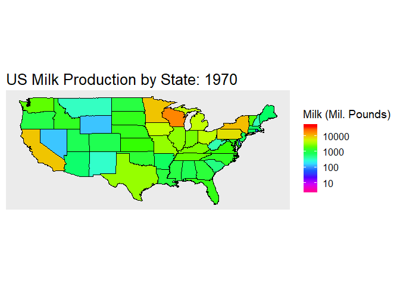

```r
# Try an animated map
# New Source: https://github.com/thomasp85/gganimate
# install.packages("cowplot")  # a gganimate dependency
# devtools::install_github("thomasp85/gganimate")
library(gganimate)
# install.packages("gifski")
library(gifski)
# A few examples from online
anim <- ggplot(mtcars, aes(mpg, disp)) +
  geom_point() +
  geom_smooth(colour = 'grey', se = FALSE) +
  geom_smooth(aes(colour = factor(gear))) +
  transition_layers(layer_length = 1, transition_length = 2) +
  enter_fade() + enter_grow()
animate(anim, fps = 20)
library(gapminder)
#View(gapminder)
gdp <- ggplot(gapminder, aes(gdpPercap, lifeExp, size = pop, colour = country)) +
  geom_point(alpha = 0.7, show.legend = FALSE) +
  scale_colour_manual(values = country_colors) +
  scale_size(range = c(2, 12)) +
  scale_x_log10() +
  facet_wrap(~continent) +
  # Here comes the gganimate specific bits
  labs(title = 'Year: {frame_time}', x = 'GDP per capita', y = 'life expectancy') +
  transition_time(year) +
  ease_aes('linear')
animate(gdp, fps = 20)

# Can we extend to our maps example??
library(transformr)
library(tweenr)
# https://github.com/thomasp85/gganimate/issues/177
# https://github.com/thomasp85/gganimate/issues/286
# https://github.com/thomasp85/transformr

milk_range <- sort(unique(state_milk$milk_produced))
lim <- c(min(milk_range), max(milk_range))

milkMapAnimated <- ggplot(data = state_milk) +
  geom_polygon(aes(x=long, y = lat, fill = milk_produced, group = group),
               color = "black") +
  coord_fixed(1) +
  scale_fill_gradientn(colours = rev(rainbow(10)), limits = lim,
                      trans = "log10") +
  ditch_the_axes + #removes axes
  transition_manual(as.factor(year)) +
  ease_aes('linear') +
  labs(title = 'US Milk Production by State: {current_frame}',
       fill = "Milk (Mil. Pounds)")
animate(milkMapAnimated, fps = 20, renderer = gifski_renderer(loop = TRUE))
```

```r
# anim_save("MilkMapAnimation.gif", animation = milkMapAnimated, path = path)
```

## Formatting Data for Plotting

```r
# Scatter plot of milk production over time by state
milkTime <- ggplot(state_milk, aes(x=year, y=milk_produced)) +
  geom_path(aes(col=region)) +
#  geom_smooth(method="loess", se=F) +
  xlim(c(1970, 2017)) +
  ylim(c(0, 500000)) +
  labs(x= "Year",
       y="Milk Produced (Millions of Pounds)",
       title="Milk Production by State over Time")

rank_states_milk <- state_milk_2017 %>% arrange(desc(milk_produced)) %>% dplyr::select(region) %>% unique()
```

Consider trying to plot a similar line graph, except for the milk_facts data. Each observation of this dataset is one year, and the corresponding average dairy consumption in pounds per person across the different types of dairy products. As a data table, the milk_facts dataset is concise and appealing. However, for plotting with ggplot2, we would prefer to specify “dairy consumption” as the dependent variable, and give a different line to each category of dairy. We can very easily convert the data to the desired long format using the melt function from the reshape2 package.

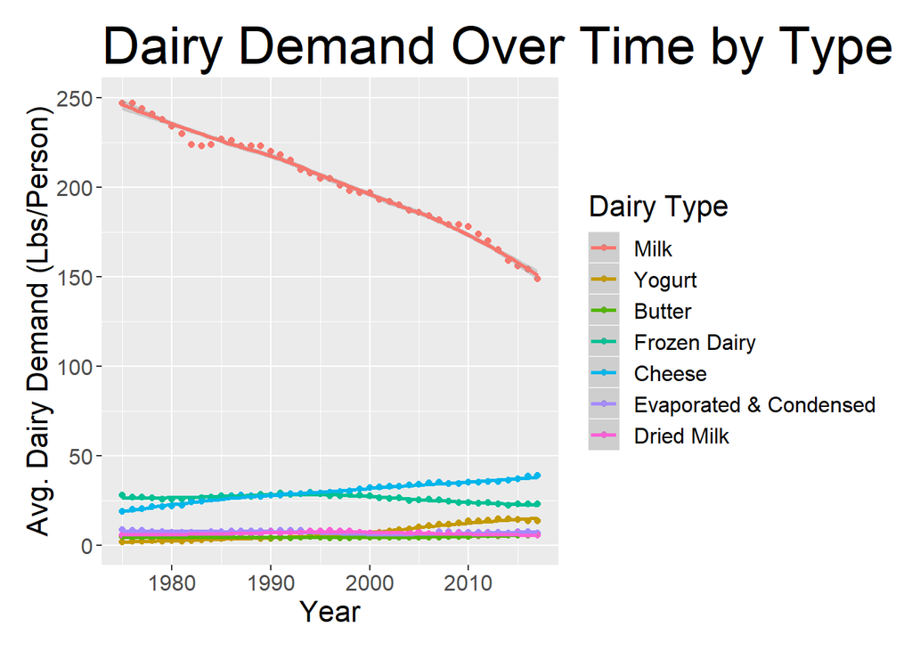

```r
#First, we aggregate a few columns
milk_facts <- milk_facts %>%
  mutate(`Frozen Dairy` = frozen_ice_cream_regular +
           frozen_ice_cream_reduced_fat +
           frozen_sherbet + frozen_other) %>%
  mutate(`Cheese` = cheese_american + cheese_cottage + cheese_other) %>%
  mutate(`Evaporated & Condensed` = evap_cnd_canned_whole_milk +
           evap_cnd_bulk_whole_milk +
           evap_cnd_bulk_and_can_skim_milk) %>%
  mutate(`Dried Milk` = dry_whole_milk + dry_nonfat_milk +
           dry_buttermilk + dry_whey) %>%
  rename(Milk = fluid_milk, Yogurt = fluid_yogurt, Butter = butter)

# Convert data to long format to be able to plot multiple "y" variables as a single response
library(reshape2)
milk_facts_long <- melt(milk_facts, id = "year") %>%
  rename(cons_lbs_per_person = value, dairy_type = variable) %>%
  filter(dairy_type %in% c("Milk", "Yogurt", "Butter",
                           "Frozen Dairy", "Cheese",
                           "Evaporated & Condensed", "Dried Milk"))
View(milk_facts_long)

#Plot the line graph
dairyTime <- ggplot(milk_facts_long, aes(x = year,
                                         y = cons_lbs_per_person,
                                         col = dairy_type)) +
  geom_point() +
  geom_smooth(method="loess", se=TRUE) +
  xlim(c(1975, 2017)) +
  labs(x= "Year",
       y="Avg. Dairy Demand (Lbs/Person)",
       title="Dairy Demand Over Time by Type",
       col = "Dairy Type") +  #Change text size
  theme(title = element_text(size =24),
        strip.text.x = element_text(size = 10),
        axis.title = element_text(size = 16),
        axis.text.y = element_text(size = 12),
        axis.text.x = element_text(size =12),
        legend.title = element_text(size = 16),
        legend.text = element_text(size = 12),
        plot.margin = unit(c(5, 5, 5, 5), "mm")
        )
dairyTime
```

```r
#Save the plot to your folder
path <- "C:/Users/eshee/Box Sync/Documents/Penn State Statistics/Research/B2D2K/ggplot2_tutorial"
# ggsave(filename = "Fig2-dairyDemandByTimeType.png",
#        plot = last_plot(),width = 26, height = 22, units = "cm",
#        dpi = 300, device = "png", path = path)      #save plot
```